# Assignment_4_Yue_Ma

Yue Ma

12/03/2018

# 1 Smooth Nonlinear Models for a Continuous Outcome

```r
data(College, package = "ISLR")
str(College, max.level = 1)
```

```
## 'data.frame':    777 obs. of  18 variables:
##  $ Private    : Factor w/ 2 levels "No","Yes": 2 2 2 2 2 2 2 2 2 2 ...
##  $ Apps       : num  1660 2186 1428 417 193 ...
##  $ Accept     : num  1232 1924 1097 349 146 ...
##  $ Enroll     : num  721 512 336 137 55 158 103 489 227 172 ...
##  $ Top10perc  : num  23 16 22 60 16 38 17 37 30 21 ...
##  $ Top25perc  : num  52 29 50 89 44 62 45 68 63 44 ...
##  $ F.Undergrad: num  2885 2683 1036 510 249 ...
##  $ P.Undergrad: num  537 1227 99 63 869 ...
##  $ Outstate   : num  7440 12280 11250 12960 7560 ...
##  $ Room.Board : num  3300 6450 3750 5450 4120 ...
##  $ Books      : num  450 750 400 450 800 500 500 450 300 660 ...
##  $ Personal   : num  2200 1500 1165 875 1500 ...
##  $ PhD        : num  70 29 53 92 76 67 90 89 79 40 ...
##  $ Terminal   : num  78 30 66 97 72 73 93 100 84 41 ...
##  $ S.F.Ratio  : num  18.1 12.2 12.9 7.7 11.9 9.4 11.5 13.7 11.3 11.5 ...
##  $ perc.alumni: num  12 16 30 37 2 11 26 37 23 15 ...
##  $ Expend     : num  7041 10527 8735 19016 10922 ...
##  $ Grad.Rate  : num  60 56 54 59 15 55 63 73 80 52 ...
```

1. Use the createDataParition function to split the observations into training and testing.

```r
library(caret)
set.seed(1796990821)
in_train <- createDataPartition(y = College$Outstate,
                                p = 3 / 4, list = FALSE)
str(in_train)
```

```
##  int [1:584, 1] 1 2 3 4 5 7 8 9 10 11 ...
##  - attr(*, "dimnames")=List of 2
##   ..$ : NULL
##   ..$ : chr "Resample1"
```

```r
college_training <- College[ in_train, ]
college_testing  <- College[-in_train, ]
```

2. Use the lm() function to predict Outstate using whatever transformations, polynomials, cuts, and interactions you feel are necessary to predict well in the testing data.

```r
fit1 <- train(Outstate ~ Expend, data = college_training, method = "lm", preProcess = c("center", "scale"))
y_hat1 <- predict(fit1, newdata = college_testing)
defaultSummary(data.frame(obs = college_testing$Outstate, pred = y_hat1))
```

```
##         RMSE     Rsquared          MAE
## 2728.8727270    0.5011428 2174.1965288
```

```r
MSE1 <- 2728.8727270^2
MSE1
```

```
## [1] 7446746
```

```r
fit2 <- train(Outstate ~ Expend + S.F.Ratio, data = college_training, method = "lm", preProcess = c("center", "scale"))
y_hat2 <- predict(fit2, newdata = college_testing)
defaultSummary(data.frame(obs = college_testing$Outstate, pred = y_hat2))
```

```
##         RMSE     Rsquared          MAE
## 2649.1714928    0.5286851 2129.9341461
```

```r
MSE2 <- 2649.1714928^2
MSE2
```

```
## [1] 7018110
```

From the results above we can see, the last lm model produces the lowest mean squared error.

3. Use caret to fit a Generalized Additive Model where Outstate is the outcome using the predictors from your best model for the training data in part (b). Explain what calling plot() on the finalModel list element tells you.

```r
library(gam)
```

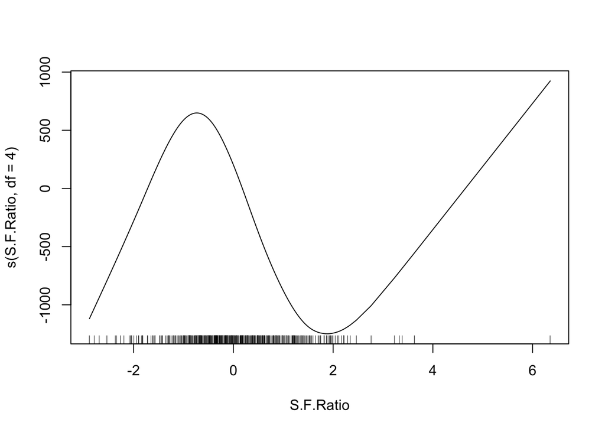

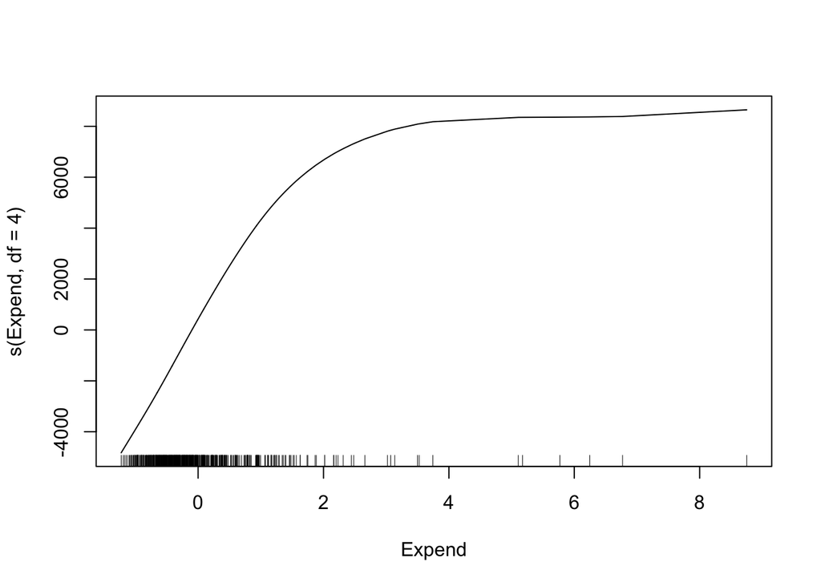

```r
ctrl <- trainControl("cv", number = 10)
GAM_grid <- data.frame(df = 1:10)
GAM <- train(Outstate ~ S.F.Ratio + Expend, data = college_training, method = "gamSpline", trControl = ctrl, tuneGrid = GAM_grid, preProcess = c("center", "scale"))
plot(GAM$finalModel)
```

4. Which predictors, if any, exhibit a very non-linear relationship with Outstate, conditional on the other predictors?

Yes, both the Instructional expenditure per student (Expend) and Student/faculty ratio (S.F.Ratio) exhibit a non-linear relationship with Outstate.

5. Is the average squared error in the testing data greater, less than, or about the same than with lm?

```r
defaultSummary(data.frame(obs = college_testing$Outstate, pred = predict(GAM, newdata = college_testing)))
```

```
##         RMSE     Rsquared          MAE
## 2184.6078873    0.6785868 1777.0987169
```

```r
MSE3 <- 2184.6078873^2
MSE3
```

```
## [1] 4772512
```

For the lm model, the MSE is 7018110, and the MSE in the testing data with GAM is 4772512, much less than that in lm model.

# 2 Fused Lasso Additive Model

1. In your own words, describe what the Fused Lasso Additive Model does

The fused lasso additive model is an approach to fit an additive model in which each component is estimated to be piecewise constant with a small number of adaptively-chosen knots.

It is the solution to a convex optimization problem, for which a simple algorithm with guaranteed convergence to a global optimum is provided. Also, it is shown to be consistent in high dimensions, and an unbiased estimator of its degrees of freedom is proposed.

2. Use the flamCV function in the flam package to find the optimal values of the tuning parameters and estimate the coefficients of a model with the same predictors as in problem 1. Does the Fused Lasso Additive Model predict better in the testing data than the Generalized Additive Model?

```r
library(flam)
set.seed(1796990821)
flam.out <- flam(x = college_training$S.F.Ratio, y = college_training$Expend, alpha.seq = c(0.8, 0.9, 1))
flamCV.out <- flamCV(x = college_training$S.F.Ratio, y = college_training$Expend, alpha = 1, n.fold = 2)
```

```
## [1] "fold: 1"
## [1] "fold: 2"
```

```r
alpha <- flamCV.out$alpha
lambda <- flamCV.out$lambda.cv
new.x <- college_testing$S.F.Ratio + college_testing$Expend
y_hat3 <- predict(flamCV.out$flam.out, new.x = new.x, lambda = lambda, alpha = alpha)

defaultSummary(data.frame(obs = college_testing$Outstate, pred = y_hat3))
```

```
##     RMSE Rsquared      MAE
## 4961.725       NA 3811.480
```

The RMSE of FLAM is more than that of GAM, so the MSE of FLAM is more than that of GAM as well. In this case, the FLAM does not predict better in the testing data than the GAM.

# 3 Tree-Based Models for a Binary Outcome

```r
payback <- readRDS("payback.rds")
```

1. Use the createDataParition function to split the observations into training and testing.

```r
set.seed(1796990821)
in_train1 <- createDataPartition(y = payback$y,
                                p = 3 / 4, list = FALSE)
str(in_train)
```

```
##  int [1:584, 1] 1 2 3 4 5 7 8 9 10 11 ...
##  - attr(*, "dimnames")=List of 2
##   ..$ : NULL
##   ..$ : chr "Resample1"
```

```r
loan_training <- payback[ in_train1, ]
loan_testing  <- payback[-in_train1, ]
```

2. Fit a logit model to the outcome in the training data, using whatever transformations, polynomials, cuts, and interactions you feel are necessary to predict well in the testing data.

```r
logit <- glm(y ~ int_rate + term + loan_amnt + annual_inc, data = loan_training, family = binomial(link = "logit"))
y_hat_logit <- predict(logit, newdata = loan_testing, type = "response")
defaultSummary(data.frame(obs = loan_testing$y, pred = y_hat_logit))
```

```
##       RMSE   Rsquared        MAE
## 0.34638198 0.04983727 0.23642716
```

```r
MSE4 <- 0.34638198^2
MSE4
```

```
## [1] 0.1199805
```

3. Use a boosting and then a single-tree approach to fit the outcome in the training data.

Boosting approach.

```r
library(gbm)
gbm_loan <- gbm(y ~ int_rate + term + loan_amnt + annual_inc, data = loan_training, distribution = "bernoulli", n.trees = 5000, interaction.depth = 4)
y_hat4 <- predict(gbm_loan, newdata = loan_testing, n.trees = 5000)
defaultSummary(data.frame(obs = loan_testing$y, pred = exp(y_hat4)))
```

```
##        RMSE    Rsquared         MAE
## 0.915926350 0.003045857 0.328639178
```

```r
MSE5 <- 0.915926350^2
MSE5
```

```
## [1] 0.8389211
```

A single-tree approach.

```r
ctrl <- trainControl(method = "cv", number = 10)
payback$y <- as.factor(payback$y)
out2 <- train(y ~ int_rate + term + loan_amnt + annual_inc, data = loan_training, method = "rpart2", tuneLength = 10, trControl = ctrl)
y_hat5 <- predict(out2, newdata = loan_testing)
defaultSummary(data.frame(obs = loan_testing$y, pred = y_hat5))
```

```
##       RMSE   Rsquared        MAE
## 0.35150626 0.02144701 0.24368305
```

```r
MSE6 <- 0.35150626^2
MSE6
```

```
## [1] 0.1235567
```

4. Rank the three approaches in parts (b) and (c) in terms of which is most likely to yield a correct classification in the testing data.

From the results above, we can see that the MSE of logit model is 0.1199805, the MSE of boosting approach is 0.8389211，the MSE of a single_tree approach is 0.1235567 Thus, the rank of the model from best to worst in this case is logit model, a single-tree approach, and boosting approach. The logit model is most likely to yield a correct classification in the testing data.